# Modeling memory and taxis to analyze migrations

E. Gurarie, S. Potluri, B. Fagan, others

2021-06-25

# Introduction

Seasonal migrations are extremely widespread among terrestrial, aquatic, avian and invertebrate species (Dingle 2014). For many species, migration is an extremely successful strategy, allowing a far greater number of individuals to inhabit landscape which might not otherwise be able to support large numbers year round (Fryxell et al. 1988). The ultimate evolutionary cause of seasonal migration, essentially, is that the energetic and survival related costs of migration are outweighed by the fitness benefits of accessing suitable seasonal resources, whether those are for energetic gain, predator avoidance, a suitable physical, biotic or social environment for reproduction (Avgar et al. 2014).

Much as the ultimate causes of migration vary across species, the proximate causes, drivers and mechanism can vary considerably across and even within species (Shaw 2016). Some migrants follow a “green wave” of spring vegetation as it flowers across altitudinal or latitudinal gradients (Bischof et al. 2012, Kölzsch et al. 2015). These migrations can be considered “tactical,” as they can occur - as an extreme simplification - purely as response to local conditions. Other migrants perform long-distance migrations in anticipation that critical resources will be available at the time of arrival at the end point of migration (**refs**). This second behavior involves the greatest trade-off between the costs of migration against the benefits of accessing resources, whether food, suitable habitat for breeding, or predator refuge, that are highly seasonal and localized (**refs**). This approach can be considered “strategic” in the sense that it is driven not by immediate cues but by a remembered anticipation (**Bracis2017?**).

Migratory species are often considered to be more vulnerable to environmental change, as a disruption in either of the seasonal ranges or along a migratory corridor can have significant negative impacts (Wilcove and Wikelski 2008, **Kauffman2021?**). On the other hand, it has been argued that migratory species might be more resilient to disruptions due to their wide-ranging mobility (Robinson et al. 2009). Clearly, the ability to perform a migration without local cues in only possible if the behavior is hard-cued or remembered. On the other hand, a strictly programmed behavior can be maladaptive if conditions change.

Diffusion-advection models have a long pedigree in animal movement modeling (Skellam 1951, Turchin 1998, Okubo and Levin 2001). These models are grounded in the general idea that animal movements - somewhat like movements of physical particles - combine a random (diffusive) component with a directed (advective) component. While direct relationships between diffusion models and movement data are somewhat tenuous (Gurarie and Ovaskainen 2011), as a theoretical tool for exploring processes they are invaluable for their versatility and the relative ease of numeric computation of the partial differential equations (PDEs) that are used to describe diffusion-advection models mathematically. Thus, much theoretical and some applied work has been done on refining the basic assumptions of diffusion models, e.g. by including heterogeneity in populations (Skalski and Gilliam 2003, Gurarie et al. 2009), fat-tailed dispersal kernels (Kot et al. 1996), non-linear or otherwise complex responses to resources and consepecifics (**refs**).

Perhaps the greatest difference between animals and randomly moving passive particles described by diffusion models is cognition, including social behavior and memory. Refinements to diffusion-advection equations have revealed conditions under which non-local information gathering (Fagan et al. 2017) and behavioral switching may confer foraging advantages (Fagan et al. 2019), in particular when resources are dynamic and patchy. The interacting role of memory and sociality, in contrast, have been comparatively little studied.

Here, we develop a diffusion-advection model with memory to explore the resilience of a migratory population under various dynamic, seasonal resource distributions. In formulating the model, our goal is to identify the minimum set of movement and memory parameters required to generate an adaptive, migratory behavior. This includes the ability to learn to migrate from a non-migratory initial conditions, simulating the release of naive animals in a seasonal environment (Jesmer et al. 2018), or to lose the propensity to migrate if the resource distribution does not require it, also a commonly observed phenomenon (**refs**). Our ultimate goal is to assess the role of long and short-term memory in the resilience (or fragility) of a migratory population against changing patterns in resource distribution that are the consequences of rapid climate change.

We anticipate that under many conditions a blending of *tactical* (i.e. direct response to resource availability or perception) and *strategic* (i.e. memory-driven and forward-thinking) behavior help foragers navigate dynamic, seasonal environments. Over-reliance on either strategy should be maladaptive. We further anticipate that a a shorter-term memory updating is needed to navigate trends in resource spatial distribution and temporal distribution (phenology), but that a longer-term reference memory is needed to navigate resource distributions that are increasingly stochastic.

# Methods

## Memory movement model

In designing our study, our goal was to develop a minimal heuristic in which the following processes were explicitly modeled: (1) Random or exploratory movement, (2) attraction to resources, (3) a long-term (or *reference*) memory of large-scale movement behavior, (4) a short-term (or *working*) memory that updates movement behavior based on recent experience, (5) some social aspect to the learned behavior.  
A diffusion-advection equation provided a computationally efficient and versatile framework for examining just such a system. We consider a population moving in one dimension in a constrained domain ${\cal D}$ and distributing itself according to the following equation:

$${\frac{\partial u}{\partial t}} = -\varepsilon {\frac{\partial^2 u}{\partial x^2}} +
\alpha \frac{\partial}{\partial x}\left(u \frac{\partial h}{\partial x}\right) +
\beta \frac{\partial}{\partial x}\left(v_s(u)\right) +
v_m(t)$$

where $u$ represents the population distributed in time and space. The first term is the diffusion term, capturing the fast time-scale exploration and “random” movements of individuals, with $\varepsilon$ is the diffusion rate.

The second term represents the attraction to a dynamic resource $h$, with the proportionality of the advection to the gradient of the resource given by the parameter $\alpha$ (note, the population and resource distributions are functions of both space and time $u(x,t)$ and $h(x,t)$ - we omit the dependent variables in the notation for brevity). This is the well-studied standard chemotaxic resource-following behavior. We borrow the general notation from our earlier related work (Fagan et al. 2017, 2019).

The third term captures the collective or social advection term of the population via a non-local, density dependent function $v_s(u,x)$. If this function takes the form of a convolution around a non-local kernel $k$, i.e.~
$$v_s(u) = k(x) * u(x)$$
and that kernel is odd, an attractive or “swarming” behavior can be generated (Mogilner and Edelstein-Keshet 1999). We use the kernel analyzed by Mogilner and Edelstein-Keshet (1999):
$$k(x) = \frac{x}{2\lambda^2} \exp(-x^2/2\lambda^2).$$
The convolution of $u$ with this kernel has the property of pushing the population in a positive direction when $x < \widehat{u}$, and in a negative direction when $x > \widehat{u}$. The parameter $\lambda$ is a length scale of sociality - roughly one-half the size of the “swarm,” which $\beta$ is a parameter which quantifies the overall strength of sociality.

Finally, the last term captures the direct advection that emerges from a memory-driven migratory behavior. This term evolves with a set of parameters $\theta_y$ that slowly change each year $y \in \{0,1,2,...\}$, i.e. the count of periods $\tau$: $y = \lfloor t/\tau \rfloor$.

The migration speed is specified by six parameters $\theta$: the timing of the start and duration of two anticipated seasons (nominally, winter and summer) $t_1$, $dt_1$, $t_2$, $dt_2$, and the spatial coordinates of the population centroid for each season $x_1$ and $x_2$. Thus the remembered migratory speed term is a simple step function given by:

$$v_m(t, \theta_y) = \begin{cases}
0 &; & t > t_1 &\text{and} & t \leq t_1 + dt_1 \\
s_{12} &; & t > t_1 + dt_1 &\text{and} & t \leq t_2 \\
0 &; & t> t_2 &\text{and} &t \leq t_2 + dt_2 \\
s_{21} &; & t > t_2+dt_2 & \text{or} & t \leq t_1\\
\end{cases}$$

where the migration speeds $s_{12}$ and $s_{21}$ from the respective ranges are set such that they arrive at $x_1$ at $t_1$, leave at $t = t_1 + dt_1$, arrive at $x_2$ at $t = t_2$, i.e. $s_{12} = \frac{x_2-x_1}{t_2 - (t_1 + dt_1)}$ and $s_{21} = \frac{x_1-x_2}{t_1 - (t_2 - \tau + dt_2)}$. This step-like migration function is a one-dimensional version of the migration parameters estimated individually (Gurarie et al. 2017) and for populations (Gurarie et al. 2019) in empirical studies.

We consider these six parameters to be the known or remembered determinants of the migratory behavior, with an initial set $\theta_0$ determining the reference migration behavior. This reference migration is updated each year by the experience of the population. To perform this updating, we estimate a new set of parameters $\widehat{\theta_y}$ after each year, and combine these new parameters with the reference parameters according to the following weighted mean:

$$\theta_{y+1} = \kappa^y \, \theta_o + \left(1-\kappa^y\right)\,\widehat{\theta_y}$$
where each of the six parameters is updated identically. The estimates $\widehat{\theta_y}$ are obtained via a least-squares minimization of the migration track ($m(t,\theta) = \int_0^t v_m(t',\theta_y) \, dt'$) against the spatial mean of the population process in year $y$ (i.e. $\widehat{u}(t) = \int_X u_y(t, x) dx$). The parameter $\kappa \in (0,1)$ captures the reliance on that long-term memory. When $\kappa = 0$, all of the actionable memory is from the preceding year. When $\kappa = 1$, the actionable memory is entirely the reference memory.

The model is confined to a one-dimensional bounded domain $[-\chi,\chi]$, with no flux outside of the boundaries i.e. ${\frac{\partial u(-\chi,t)}{\partial t}} = {\frac{\partial u(\chi,t)}{\partial t}} =0$. As there are no birth or death processes, the total population remains fixed and constant, for convenience integrating to 1. Furthermore, the parameters remain constant throughout time, with no adaptation or mutation-selection process. Our interest is entirely in the ability of a fixed set of memory and movement parameters to ``navigate’’ an intra- and interannually dynamic, seasonal environment.

## Seasonal resource

We ran our numerical experiments on a spatial domain $x \in [-100,100]$, and a periodicity $\tau = 100$ (i.e.~100 day years). We were interested in an approximately periodic resource dynamic, i.e. one in which $h(x,t \approx h(x, t-\tau))$. We generated two types of resource distributions. A “non-surfable” resource (*island resource*), and weakly surfable resource (*drifting resource*). Both are characterized by a peak in time and space centered at $m_x$ at $m_t$, and $-m_x$ at $\tau - m_t$ (for example, locations 40 and -40 at times 25 and 75, respectively). These pulses have a shared time scale of duration $s_t$ and a spatial scale of extent $s_x$, the standard deviation in the time and space dimension respectively. The island resource is simply two uncorrelated bivariate normal distributions
$$h(x,t) = K\,(\Phi(m_x, m_t, s_x, s_t) + \Phi(-m_x, \tau - m_t, s_x, s_t))$$
where $\Phi$ is the bivariate Gaussian distribution function, and the normalizing constant $K$ is selected such that the average total amount of resource throughout the year is 1, i.e. ${1 \over \tau} \int_T\int_X h(x,t) dx\,dt = 1$.

Within a given year, the resource is entirely symmetric: $h_y(x,t) = h_y(-x, \tau-t)$. However, in scenarios exploring climate change we allow the peaks to vary with drift and stochasticity according to: $m_x(y) \sim {\cal N}(\mu_x + \beta_x\,y, \sigma_x)$ and $m_t(y) \sim {\cal N}(\mu_t + \beta_t\,y, \sigma_t)$, where the $\mu$, $\beta$ and $\sigma$ terms are the mean, slope and variance, respectively, for the location and time duration of the pulse. Thus, if $\beta=0$ and $\sigma=0$, the conditions are constant across years, if $\beta_x > 0$ there is a drift of the resource towards extremes, if $\beta_t < 0$ there is a shift towards earlier resource pulses. These trends mirror the pole-ward shift of peak resources and the earlier spring phenology occurring with a warming global climate. The spatial scales ($s_x$ and $s_t$) remain constant in all of our simulations.

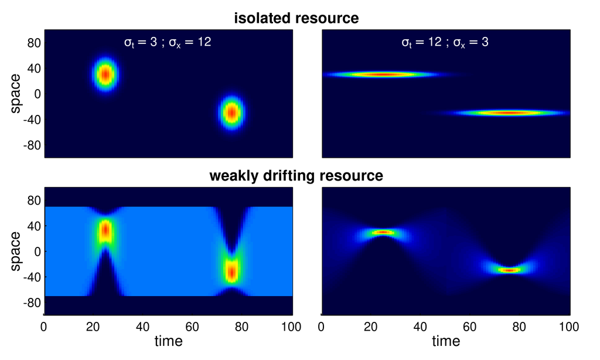

**Figure 1. Examples of various seasonal resource distribution functions, contrasting short duration, but wide pulses ($\sigma_t = 3, \sigma_x = 12$; left panels), long duration but spatially concentrated pulses ($\sigma_t = 12, \sigma_x = 3$; right panels), and isolated resource pulses (upper panels) from the weakly drifting resource (lower panels). The total amount of resource is identical across all scenarios. In the weakly drifting resources, the total amount is constant at all times, and uniform in the middle of the phase (time = 0, 50, 100).**

## Metrics

The main metrics we are interested are *migration mismatch* and *foraging efficiency*.

Migration mismatch captures the similarity between the migration phenology and the resource phenology. To do this, we compute the total mismatch, i.e. is a sum of the difference between the migration coefficients and the resource peaks. Thus, the spatial mismatch is given by the absolute difference between the migration targets and the resource peaks, i.e. $MM_x = |x_1 - m_x| + |x_2 + m_x|$. The temporal mismatch is the difference between the arrival time and the peak of the resource if arrival is post-peak, the difference between the departure time and the peak of the resource if departure is pre-peak, and 0 if the seasonal duration spans the peak, i.e. $MM_t = max\{t_1 - m_1, m_1 - (t_1 + dt_1), 0\} + max\{t_2 - m_2, m_2 - (t_2 + dt_2), 0\}$. The total mismatch is the sum of $MM_x$ and $MM_t$. If the total mismatch is less than 1, we consider the migration to be perfect. If it is between 1 and 5, we consider it to be good. Otherwise, we consider the migration to be mismatched.

To quantify the foraging efficiency, i.e., the organisms’ ability to track the distribution of the resources over space and time, we use a continuous form of the Bhattacharyya Coefficient (Bhattacharyya 1943) which quantifies the similarity between two distributions. We compute this coefficient at every time point in a given year, and take the mean across the equilibrium year to determine foraging efficiency (FE). Thus, the foraging efficiency index is:
$$FE = {1\over \tau} \int_{0}^\tau \int_{0}^{\chi} \sqrt{u(x,t) \, h(x,t)} \,\, dx\,dt$$
where the spatial integral is taken over the domain. This metric is constrained to be between 0 and 1.

For simulations with a constant resource, we run those until a quasi-equilibrium state is achieved, i.e. where the Bhattacharya index of the population distribution across subsequent years reaches a value of 0.9999. Once that state is attained, we compute the mirgatoriness and foraging efficiency metrics, and additionally collect the number of years that were required to reach stationarity.

For numerical runs with climate change, we run the simulation for 30 years, since equilibrium is never achieved) and retain the foraging efficiency for the final 10 years, reflecting something like the dynamic long-term average of the system’s ability to keep track of climate change. We also record the migration parameters $\widehat{\theta_y}$ for each year.

## Simulation studies

We explored this model using numerical differencing of a system of ordinary differential equations (ODE’s) approximating the PDE in equation (2) with the Runge-Kutte algorithm using the `deSolve` (Soetaert et al. 2010) and `ReacTran` (Soetaert and Meysman 2012) packages in R. We additionally used the `nlsLM` function in package `minpack.LM` (Elzhov et al. 2016) for robust and fast annual estimation of the migration parameters. The complete code is available as an R package (`memorymigration`) available on GitHub at https://github.com/EliGurarie/memorymigration and as an interactive Shiny application at https://url.to.be.determined.

We assessed a wide range of parameter values and resource geometries and dynamics with the goal of answering the three main questions:

1. Can this model adapt to a discrete shift in peak resource location and timing? What is the relative role of memory and sociality?
2. Can this model “acquire” a migratory behavior from a non-migratory initial condition?
3. Can this model adapt when the resource peak shifts in space and time? What is the role of the reference memory.

# Results

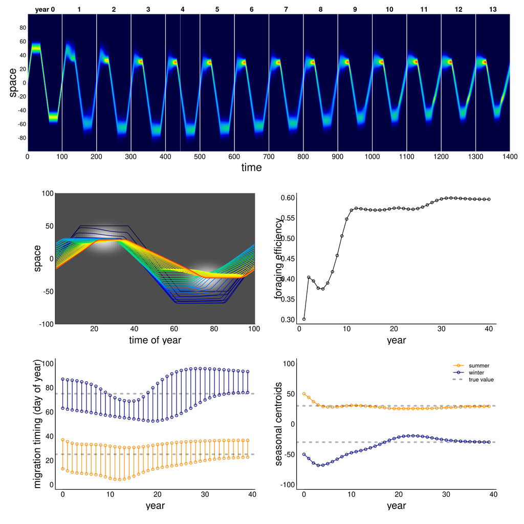

**Figure 2.** *Example of adaptation to a shift in resource peak. The initial (year 0) behavior migrates to locations 50 and -50 at days 15 and 60, whereas the resource peak is at 30 and -30, peaking at times 25 and 75. (a) shows the first 14 years of the simulation; (b) The centroid of the annual movement of the population is shown in panel b, with dark blue to red colors indicating year 0 to year 40; (c) annual foraging efficiency across years; (d) migration timing parameters for each year, with orange segments indicating arrival and departure from the summering (northern) grounds, and the blue segments indicating timing of arrival and departure at the wintering grounds; (e) migration arrival and departure location across years, with blue and orange indicating winter (southern) and summer (northern) locations.*

## Adaptation to resource phenology

The ability of this system to attain stable, migratory state that matches the dynamics of the resource is illustrated in Figure 2. In the illustrated scenario, it takes nearly 40 years to attain an equilibrium, and the eventual steady state is one where the centroid of the migration lines up exactly with the centroid of the resource, and the arrival timing coincides with the *peak* of resource availability. Notably, the path to this equilibrium is somewhat indirect, with the winter (later, more southerly) range taking more time to stabilize than the summer (earlier, more northern) range. The eventual steady state is one where the foraging efficiency is relatively high.

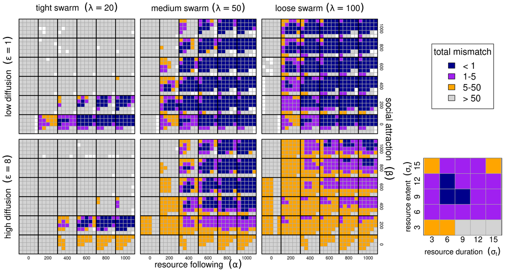

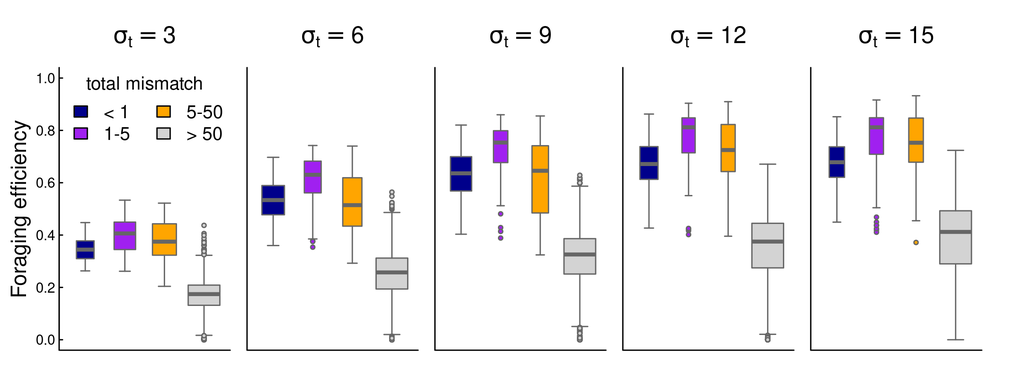

**Figure 4.** *Box-plots of foraging efficiency against mismatch across several values of foraging patch duration.*

## Learning to migrate

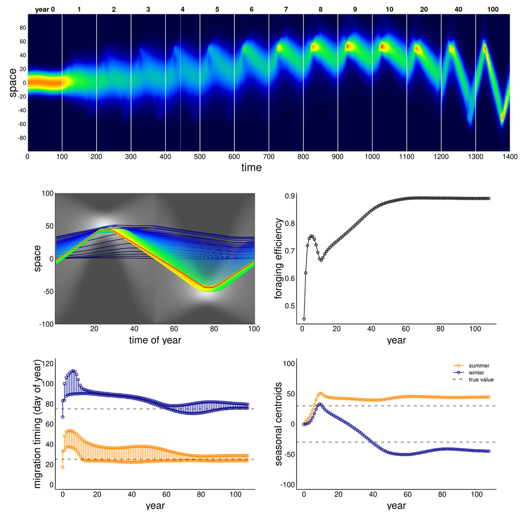

# Discussion

Our model is somewhat similar to an evolutionary individual-based model (**Anderson2013?**), which showed that some inherent phenotypic plasticity is required to hedge both against persistent trends and increased stochasticity of resource distributions, but at the risk of sub-optimal access to resources (**Anderson2013?**).

# References

Avgar, T., G. Street, and J. M. Fryxell. 2014. On the adaptive benefits of mammal migration. Canadian Journal of Zoology 92:481–490.

Bhattacharyya, A. 1943. On a measure of divergence between two statistical populations defined by their probability distributions. Bull. Calcutta Math. Soc. 35:99–109.

Bischof, R., L. E. Loe, E. L. Meisingset, B. Zimmermann, B. Van Moorter, and A. Mysterud. 2012. A migratory northern ungulate in the pursuit of spring: Jumping or surfing the green wave? The American Naturalist 180:407–424.

Breiman, L. 2001. Random forests. Machine learning 45:5–32.

Dingle, H. 2014. Migration: The biology of life on the move. Oxford University Press, USA.

Elzhov, T. V., K. M. Mullen, A.-N. Spiess, and B. Bolker. 2016. Minpack.lm: R interface to the levenberg-marquardt nonlinear least-squares algorithm found in MINPACK, plus support for bounds.

Fagan, W., E Gurarie, S. Bewick, A. Howard, R. Cantrell, and C. Cosner. 2017. Perceptual ranges, information gathering, and foraging success in dynamic landscapes. The American Naturalist 189:474–489.

Fagan, W., T. Hoffman, D. Dahiya, E Gurarie, R. Cantrell, and C. Cosner. 2019. Improved foraging by switching between diffusion and advection: Benefits from movement that depends on spatial context. Theoretical Ecology 13:127–136.

Fryxell, J. M., J. Greever, and A. Sinclair. 1988. Why are migratory ungulates so abundant? The American Naturalist 131:781–798.

Gurarie, E., J. J. Anderson, and R. W. Zabel. 2009. Continuous models of population-level heterogeneity inform analysis of animal dispersal and migration. Ecology 90:2233–2242.

Gurarie, E., F. Cagnacci, W. Peters, C. H. Fleming, J. M. Calabrese, T. Mueller, and W. F. Fagan. 2017. A framework for modelling range shifts and migrations: Asking when, whither, whether and will it return. Journal of Animal Ecology 86:943–959.

Gurarie, E., M. Hebblewhite, K. Joly, A. P. Kelly, J. Adamczewski, S. C. Davidson, T. Davison, A. Gunn, M. J. Suitor, W. F. Fagan, and others. 2019. Tactical departures and strategic arrivals: Divergent effects of climate and weather on caribou spring migrations. Ecosphere 10:e02971.

Gurarie, E., and O. Ovaskainen. 2011. Characteristic spatial and temporal scales unify models of animal movement. The American Naturalist 178:113–123.

Jesmer, B. R., J. A. Merkle, J. R. Goheen, E. O. Aikens, J. L. Beck, A. B. Courtemanch, M. A. Hurley, D. E. McWhirter, H. M. Miyasaki, K. L. Monteith, and others. 2018. Is ungulate migration culturally transmitted? Evidence of social learning from translocated animals. Science 361:1023–1025.

Kot, M., M. A. Lewis, and P. van der Driessche. 1996. Dispersal data and the spread of invading organisms. Ecology 77:2027–2042.

Kölzsch, A., S. Bauer, R. De Boer, L. Griffin, D. Cabot, K.-M. Exo, H. P. Van der Jeugd, and B. A. Nolet. 2015. Forecasting spring from afar? Timing of migration and predictability of phenology along different migration routes of an avian herbivore. Journal of Animal Ecology 84:272–283.

Mogilner, A., and L. Edelstein-Keshet. 1999. A non-local model for a swarm. Journal of Mathematical Biology 38:534–570.

Okubo, A., and S. Levin. 2001. Diffusion and Ecological Problems: Modern Perspectives. Springer Verlag, New York.

Robinson, R., H. Crick, J. Learmonth, I. Maclean, C. Thomas, F. Bairlein, M. Forchhammer, C. Francis, J. Gill, B. Godley, J. Harwood, G. Hays, B. Huntley, A. Hutson, G. Pierce, M. Rehfisch, D. Sims, B. Santos, T. Sparks, D. Stroud, and M. Visser. 2009. Travelling through a warming world: Climate change and migratory species. Endangered Species Research 7:87–99.

Shaw, A. K. 2016. Drivers of animal migration and implications in changing environments. Evolutionary Ecology 30:991–1007.

Skalski, G. T., and J. F. Gilliam. 2003. A diffusion-based theory of organism dispersal in heterogeneous populations. The American Naturalist 161:441–458.

Skellam, J. G. 1951. Random dispersal in theoretical populations. Biometrika 38:196–218.

Soetaert, K., and F. Meysman. 2012. Reactive transport in aquatic ecosystems: Rapid model prototyping in the open source software R. Environmental Modelling & Software 32:49–60.

Soetaert, K., T. Petzoldt, and R. W. Setzer. 2010. Solving differential equations in R: Package deSolve. Journal of Statistical Software 33:1–25.

Turchin, P. 1998. Quantitative analysis of movement: Measuring and modeling population redistribution in animals and plants. Sinauer Associates.

Wilcove, D. S., and M. Wikelski. 2008. Going, going, gone: Is animal migration disappearing. PLoS Biology 6:e188.